# Homework 0

** This assignment will not be graded, but you must complete and submit it. **

## Part 1: Explore the Jupyter notebook environment.

Familiarize yourself with the Jupyter notebook environment by following these steps.

1. Use the 'View' menu to show the Table of Contents. This allows you to skip around the file more easily.
2. Notice that some blocks/cells are for runnable code and some contain text (using Markdown for simple formatting). You can change the type using the dropdown in the menu above.
3. Double click on a markdown block to edit the text. After editing, you'll need to Run the cell to render it again. **To Run a cell (code cells too!), click on it then use the play button above or the shortcut [command/control]+Return.**
4. Click anywhere in the file except for in a code cell. Press Shift+L simultaneously to show and hide line numbers.
5. Skim through the menus to identify other useful features; for example, more shortcuts or how to adjust the font size (Settings -> Theme).

## Part 2: Load Data

First, make sure that you saved the folder named HW 0 in your Neuro 120 directory.

Below, you'll load a data file containing neural activity recorded from an animal's brain while it viewed visual stimuli. The stimuli are called drifting gratings, and they were presented at several different orientations. Run the cell below to view an example.

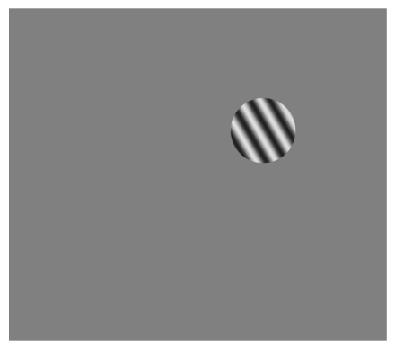

```python
import matplotlib.pyplot as plt
import matplotlib.image as mpimg

img = mpimg.imread("DriftingGrating.png")
plt.imshow(img)
plt.axis('off')
plt.show()
```

**Run the following cells to load the data file.**

X is a matrix of spike counts from 112 neurons (rows) over 1000 trials (columns).  
Y is a matrix of the one-hot encoded orientations (rows) for each trial (columns).  
AllOrientations lists the orientations that were tested as part of this dataset.

```python
import numpy as np

data = np.load('TestDataset.npz', allow_pickle=True)
```

```python
# Extract the data from the dictionary to arrays.
X=data['x']
Y=data['y']
AllOrientations=data['AllOrientations']
# Get the orientations (in degrees) for each trial
# from the one-hot encoded labels in y
Orientations=(AllOrientations[np.argmax(Y,axis=0)]).astype(int)
```

### TODO: Write a line of code to display the orientation on trial 7.

```python
# Print orientation on a specified trial

print(Orientations[6])
```

```
330
```

## Part 3: Save and Submit

Before saving, run all cells (Run -> Run All Cells).

Save this file as an **.html** (File -> Save and Export Notebook As -> HTML).

Submit the assignment in Canvas by uploading **BOTH** the **.html** and a **.ipynb** file.